# Problem Set 6

Your Name Here

Due October 30, 2025

In this problem set, we will explore some common issues with *staggered treatment DID* setups.

Run the following code to create a data set of 1000 unique units. Individuals in half the states are marked as treated.

```r
  unit <- tibble(
    unit = 1:1000,
    unit_fe = rnorm(1000, 0, 0.5),
    # generate state
    state = sample(rep(1:50, 20), 1000, replace = FALSE),
    # generate treatment groups
    treat_group = ifelse(state >= 26, 1, 0),
    # avg yearly treatment effects by group
    hat_gamma = case_when(
      treat_group == 1 ~ 2,
      TRUE ~ 0
    )) %>%
    # generate unit specific yearly treatment effects
    rowwise() %>%
    mutate(gamma = ifelse(treat_group == 1, rnorm(1, hat_gamma, .2), 0)) %>%
    ungroup()
```

```r
  year <- tibble(
    year = 1980:2015,
    year_fe = rnorm(36, 0, 0.5))

  # full interaction of unit X year
DiD_not_staggered <-  crossing(unit, year) %>%
    # make error term and get treatment indicators and treatment effects
    mutate(error = rnorm(nrow(.), 0, 0.5),
           treat = ifelse(treat_group == 1 & year >= 1998, 1, 0),
           tau = ifelse(treat == 1, gamma, 0)) %>%
    # calculate the dep variable
    mutate(dep_var = unit_fe + year_fe + tau + error)
```

Run this code to collapse the data by group and plot the time series of the average outcomes.

[output not shown]

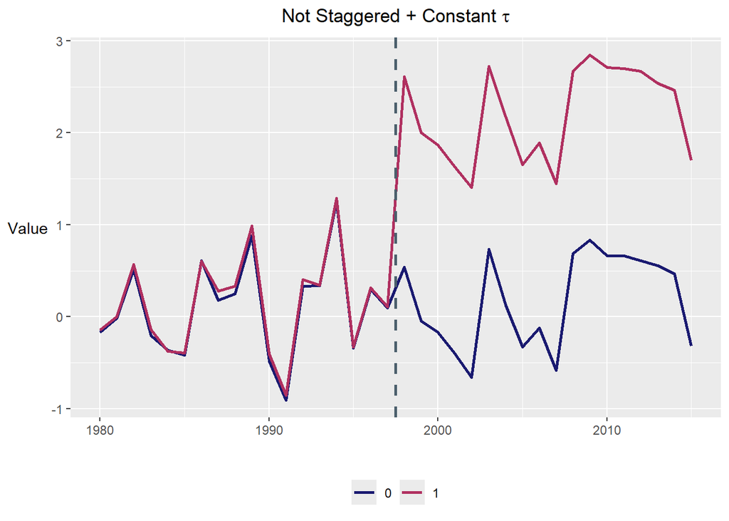

```r
  ggplot(aes(x = year, y = dep_var, group = unit), data = DiD_not_staggered) +
  # group specific averages
  geom_line(
    data = . %>%
      group_by(treat_group, year) %>%
      summarize(dep_var = mean(dep_var)),
    aes(x = year, y = dep_var, group = factor(treat_group),
        color = factor(treat_group)), size = 1) +
  labs(x = "", y = "Value", color = "Group") +
  geom_vline(xintercept = 1997.5, color = '#4B5F6C',
             linetype = "dashed", size = 1) +
  scale_color_manual(values = c("midnightblue", "maroon")) +
  ggtitle(expression(paste("Not Staggered + Constant ", tau))) +
  theme(legend.position = 'bottom',
        legend.title = element_blank(),
        plot.title = element_text(hjust = 0.5),
        plot.subtitle = element_text(hjust = 0.5),
        axis.title.y = element_text(hjust = 0.5, vjust = 0.5, angle = 360))
```

How big would you say the treatment effect is in this data?

**Based on the plotted time series, the treatment effect is about 2 units.**

Now, write some code to estimate the standard TWFE model, including *unit* and *year* fixed effects. The dependent variable is called *dep_var* and the treatment indicator is called *treat*

```r
twfe_not_staggered <- plm(dep_var ~ treat,
                          data = DiD_not_staggered,
                          index = c("unit", "year"),
                          model = "within",
                          effect = "twoways")

summary(twfe_not_staggered)$coefficients
```

```
##       Estimate Std. Error  t-value Pr(>|t|)
## treat 1.983318 0.01068433 185.6287        0
```

Now, write some code that simulates the above code 1,000 times and create a density plot of the estimates. To do this, copy everything from the second and third code chunks of this file into the simulation, then also include the regression you just ran. For each round, save the coefficient estimate that you get from the this regression on *treat*

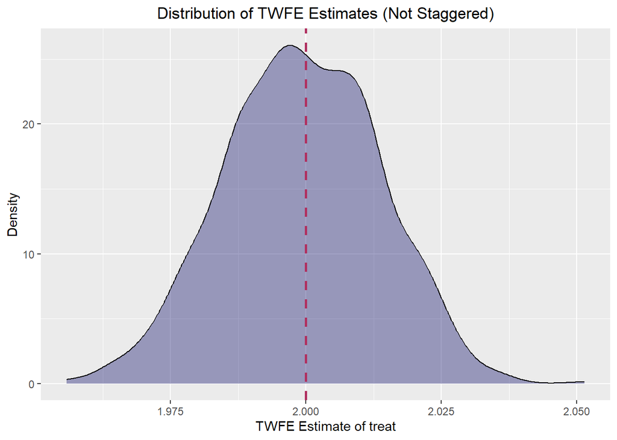

```r
df <- data.frame(matrix(ncol = 2, nrow = 1000))
colnames(df) <- c("iteration", "estimate")

for (i in 1:1000) {
   unit <- tibble(
    unit = 1:1000,
    unit_fe = rnorm(1000, 0, 0.5),
    state = sample(rep(1:50, 20), 1000, replace = FALSE),
    treat_group = ifelse(state >= 26, 1, 0),
    hat_gamma = case_when(
      treat_group == 1 ~ 2,
      TRUE ~ 0
    )) %>%
    rowwise() %>%
    mutate(gamma = ifelse(treat_group == 1, rnorm(1, hat_gamma, .2), 0)) %>%
    ungroup()

   year <- tibble(
    year = 1980:2015,
    year_fe = rnorm(36, 0, 0.5))

  DiD_not_staggered <- crossing(unit, year) %>%
    mutate(error = rnorm(nrow(.), 0, 0.5),
           treat = ifelse(treat_group == 1 & year >= 1998, 1, 0),
           tau = ifelse(treat == 1, gamma, 0)) %>%
    mutate(dep_var = unit_fe + year_fe + tau + error)

   twfe_not_staggered <- plm(dep_var ~ treat,
                            data = DiD_not_staggered,
                            index = c("unit", "year"),
                            model = "within",
                            effect = "twoways")

   df[i, 1] <- i
  df[i, 2] <- summary(twfe_not_staggered)$coefficients[1, 1]
}

ggplot(df, aes(x = estimate)) +
  geom_density(fill = "midnightblue", alpha = 0.4) +
  geom_vline(xintercept = 2, color = "maroon", linetype = "dashed", size = 1) +
  labs(x = "TWFE Estimate of treat", y = "Density",
       title = "Distribution of TWFE Estimates (Not Staggered)") +
  theme(plot.title = element_text(hjust = 0.5))
```

Given this distribution of estimates, how do we feel about using TWFE to estimate DiD treatment effects in settings like this with no staggered treatment and with constant treatment effects?

**I feel good about using the TWFE to estimate the DiD treatment effects. The distribution plots shows that the estimates are fairly centered on 2.0, which is the true treatment effect observed in the first plot above. This means that the TWFE is unbiased and fairly precise in this setting. The TWFE is able to work because every observation is treated at the same time (not staggered) and the effect is constant over time.**

The following code recreates the same regression but with *staggered treatment*, with 10 states getting treated in 1985, 10 getting treated in 1995, and 10 getting treated in 2005. Now the dataframe is called *DiD_staggered*.

```r
  unit <- tibble(
    unit = 1:1000,
    unit_fe = rnorm(1000, 0, 0.5),
    # generate state
    state = sample(rep(1:50, 20), 1000, replace = FALSE),
    # generate treatment groups
    treat_group = ifelse(state > 40, 1,
                         ifelse(state <=40 & state > 30, 2,
                                ifelse(state<=30 & state>20,3,0))),
    # avg yearly treatment effects by group
    hat_gamma = case_when(
      treat_group >= 1 ~ 2,
      TRUE ~ 0
    )) %>%
    # generate unit specific yearly treatment effects
    rowwise() %>%
    mutate(gamma = ifelse(treat_group >= 1, rnorm(1, hat_gamma, .2), 0)) %>%
    ungroup()

  year <- tibble(
    year = 1980:2015,
    year_fe = rnorm(36, 0, 0.5))

  # full interaction of unit X year
  DiD_staggered <-  crossing(unit, year) %>%
    # make error term and get treatment indicators and treatment effects
    mutate(error = rnorm(nrow(.), 0, 0.5),
           treat = ifelse(treat_group == 1 & year >= 1985, 1,
                          ifelse(treat_group == 2 & year >= 1995, 1,
                                 ifelse(treat_group == 3 & year >= 2005, 1, 0))),
           tau = ifelse(treat == 1, gamma, 0)) %>%
    # calculate the dep variable
    mutate(dep_var = unit_fe + year_fe + tau + error)

  plm_staggered <- plm(dep_var ~ treat + factor(state),
          data = DiD_staggered, index = c('unit','year'), model = 'within',
          effect = 'twoways')
  summary(plm_staggered)$coefficients
```

```
##       Estimate  Std. Error  t-value Pr(>|t|)
## treat  1.99838 0.009920016 201.4492        0
```

Now, run the following code to create an updated version of the graph above

[output not shown]

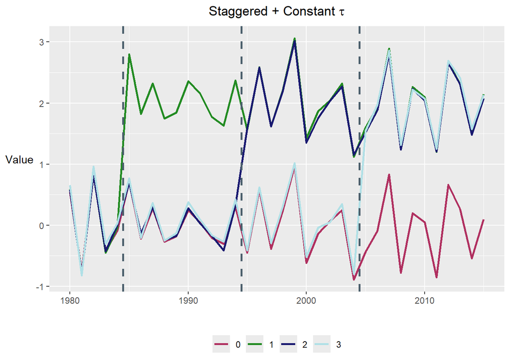

```r
  ggplot(aes(x = year, y = dep_var, group = unit), data = DiD_staggered) +
  # group specific averages
  geom_line(
    data = . %>%
      group_by(treat_group, year) %>%
      summarize(dep_var = mean(dep_var)),
    aes(x = year, y = dep_var, group = factor(treat_group),
        color = factor(treat_group)), size = 1) +
  labs(x = "", y = "Value", color = "Group") +
  geom_vline(xintercept = 1984.5, color = '#4B5F6C',
             linetype = "dashed", size = 1) +
  geom_vline(xintercept = 1994.5, color = '#4B5F6C',
             linetype = "dashed", size = 1) +
  geom_vline(xintercept = 2004.5, color = '#4B5F6C',
             linetype = "dashed", size = 1) +
  scale_color_manual(values = c("maroon", "forestgreen","midnightblue","powderblue")) +
  ggtitle(expression(paste("Staggered + Constant ", tau))) +
  theme(legend.position = 'bottom',
        legend.title = element_blank(),
        plot.title = element_text(hjust = 0.5),
        plot.subtitle = element_text(hjust = 0.5),
        axis.title.y = element_text(hjust = 0.5, vjust = 0.5, angle = 360))
```

Now that we have staggered treatment, we can view the “Goodman-Bacon Decomposition” graph using the code below:

```r
df_bacon <- bacon(dep_var ~ treat,
                   data = DiD_staggered,
                   id_var = "unit",
                   time_var = "year")
```

```
##                       type  weight avg_est
## 1 Earlier vs Later Treated 0.12876 2.01176
## 2 Later vs Earlier Treated 0.23176 1.98871
## 3     Treated vs Untreated 0.63948 1.99919
```

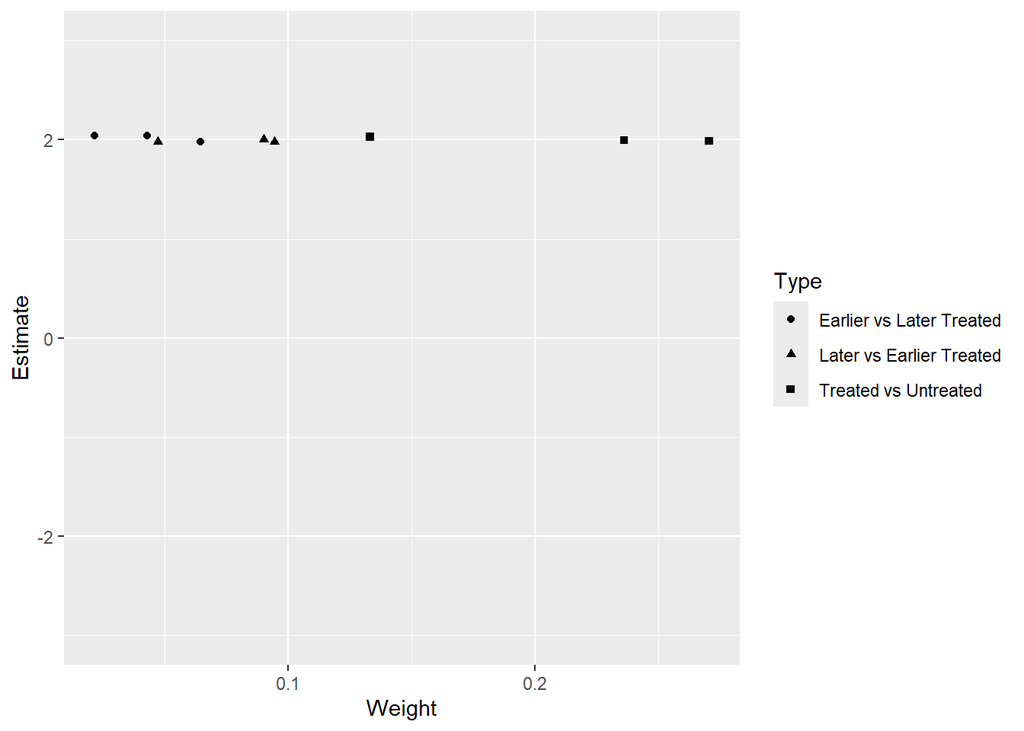

```r
ggplot(df_bacon) +
  aes(x = weight, y = estimate, shape = factor(type)) +
  labs(x = "Weight", y = "Estimate", shape = "Type") +
  geom_point() +
  ylim(-3,3)
```

Looking at the graph and the estimated coefficient, do you think we have a problem with bias using TWFE on units with staggered treatment and constant treatment effects? Why or why not?

**We do not have a bias using TWFE on staggered treatment because the TWFE is a weighted average of all the possible 2x2 DiD models. The already treated units will act as control for the future treated units, so bias may come into play here, but because the early moving group’s treatment effect stays constant around 2 (shown by the Goodman-Bacon Decomposition plot) the shift from the treatment effect gets differenced out. Essentially, the already treated controls stay constant and thus follow the same trend the future treated units would have followed without treatment, satisfying the parallel trends assumption.**

Now, we will incorporate **staggered treatment** with **heterogeneous treatment effects**, with our specific case being treatment effects that grow over time. Instead of a jump of two units at treatment, we will now have a treatment effect that grows at an average of .3 units per year.

```r
  unit <- tibble(
    unit = 1:1000,
    unit_fe = rnorm(1000, 0, 0.5),
    # generate state
    state = sample(rep(1:50, 20), 1000, replace = FALSE),
    # generate treatment groups
    treat_group = ifelse(state > 40, 1,
                         ifelse(state <=40 & state > 30, 2,
                                ifelse(state<=30 & state>20,3,0))),
    # avg yearly treatment effects by group
    hat_gamma = case_when(
      treat_group >= 1 ~ .3,
      TRUE ~ 0
    )) %>%
    # generate unit specific yearly treatment effects
    rowwise() %>%
    mutate(gamma = ifelse(treat_group >= 1, rnorm(1, hat_gamma, .1), 0)) %>%
    ungroup()

  year <- tibble(
    year = 1980:2015,
    year_fe = rnorm(36, 0, 0.5))

  # full interaction of unit X year
  DiD_staggered_heterogeneous <-  crossing(unit, year) %>%
    # make error term and get treatment indicators and treatment effects
    mutate(error = rnorm(nrow(.), 0, 0.5),
           treat = ifelse(treat_group == 1 & year >= 1985, 1,
                          ifelse(treat_group == 2 & year >= 1995, 1,
                                 ifelse(treat_group == 3 & year >= 2005, 1, 0))),
           tau = ifelse(treat == 1, gamma, 0)) %>%
    group_by(unit) %>%
    mutate(cumtau = cumsum(tau)) %>%
    mutate(dep_var = unit_fe + year_fe + cumtau + error)
```

Here is the graph to help visualize this:

[output not shown]

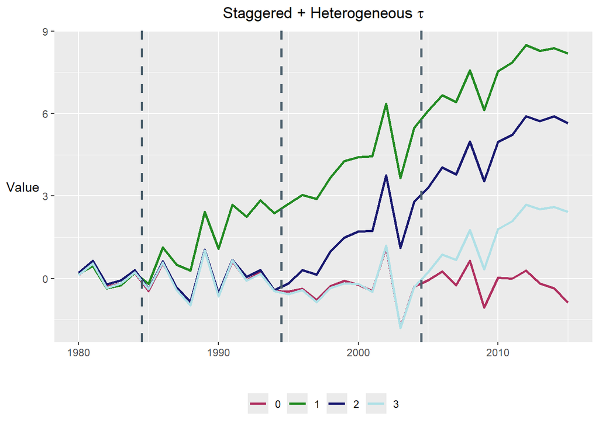

```r
  ggplot(aes(x = year, y = dep_var, group = unit), data = DiD_staggered_heterogeneous) +
  # group specific averages
  geom_line(
    data = . %>%
      group_by(treat_group, year) %>%
      summarize(dep_var = mean(dep_var)),
    aes(x = year, y = dep_var, group = factor(treat_group),
        color = factor(treat_group)), size = 1) +
  labs(x = "", y = "Value", color = "Group") +
  geom_vline(xintercept = 1984.5, color = '#4B5F6C',
             linetype = "dashed", size = 1) +
  geom_vline(xintercept = 1994.5, color = '#4B5F6C',
             linetype = "dashed", size = 1) +
  geom_vline(xintercept = 2004.5, color = '#4B5F6C',
             linetype = "dashed", size = 1) +
  scale_color_manual(values = c("maroon", "forestgreen","midnightblue","powderblue")) +
  ggtitle(expression(paste("Staggered + Heterogeneous ", tau))) +
  theme(legend.position = 'bottom',
        legend.title = element_blank(),
        plot.title = element_text(hjust = 0.5),
        plot.subtitle = element_text(hjust = 0.5),
        axis.title.y = element_text(hjust = 0.5, vjust = 0.5, angle = 360))
```

Now, the ATE is a slightly more complicated concept, but we can calculate it by taking the average value of “cumtau” for all the units where treat == 1. Write some code to do that below:

```r
ATE <- DiD_staggered_heterogeneous |>
  ungroup() |>
  filter(treat == 1) |>
  summarize(ATE = mean(cumtau))

ATE
```

```
## # A tibble: 1 × 1
##     ATE
##   <dbl>
## 1  3.74
```

Now run the TWFE specification. Does TWFE capture the ATE? If not, which direction is it biased?

```r
plm_staggered_het <- plm(dep_var ~ treat,
                         data = ungroup(DiD_staggered_heterogeneous),
                         index = c("unit", "year"),
                         model = "within",
                         effect = "twoways")

summary(plm_staggered_het)$coefficients
```

```
##       Estimate Std. Error  t-value Pr(>|t|)
## treat 1.802641 0.02684053 67.16118        0
```

This code will plot the Bacon Decomp graph, do you see anything that concerns you?

```r
df_bacon <- bacon(dep_var ~ treat,
                   data = DiD_staggered_heterogeneous,
                   id_var = "unit",
                   time_var = "year")
```

```
##                       type  weight  avg_est
## 1 Earlier vs Later Treated 0.12876  2.14982
## 2 Later vs Earlier Treated 0.23176 -1.84640
## 3     Treated vs Untreated 0.63948  3.05521
```

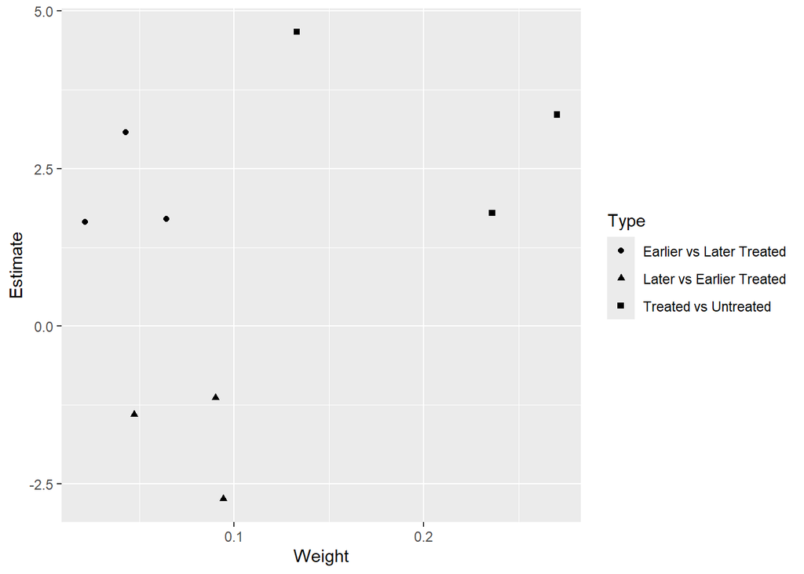

```r
ggplot(df_bacon) +
  aes(x = weight, y = estimate, shape = factor(type)) +
  labs(x = "Weight", y = "Estimate", shape = "Type") +
  geom_point()
```

**The Goodman-Bacon decomposition shows that the earlier vs later treatment effects are not constant, which biases the TWFE via it’s controlling mechanism. Essentially, the earlier treated trends are not constant, so they do not accurately act as controls for the later treated trends, which makes the observed treatment effect biased.**

*EXTRA CREDIT OPPORTUNIY*

For up to .5 additional points (20% of the assignment), create a simulation that runs 1,000 iterations of the staggered DiD *with* heterogeneous treatment timing, where you vary the amount of staggering in each round. Have the middle treated group receive treatment in 1998, but then choose a random number between 1 and 15 called stag_level, where if stag_level is 3 then the early treated group gets treatment in 1998 - 3 = 1995 and the later treated group gets treatment in 1998 + 3 = 2001. With each iteration, calculate the ATE and calculate the bias in TWFE by taking the absolute value of the difference between the ATE and the coefficient from TWFE. Finally, create a scatter plot with stag_level on the y-axis and twfe_bias on the x-axis.

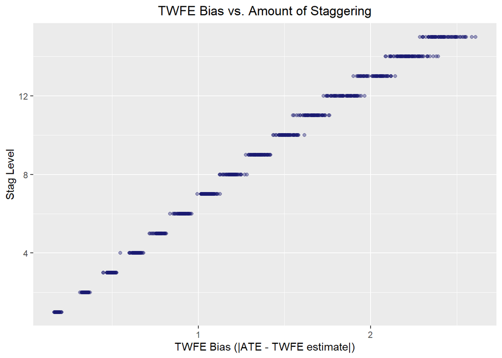

```r
df_stag <- data.frame(matrix(ncol = 5, nrow = 1000))
colnames(df_stag) <- c("iteration", "stag_level", "ATE", "twfe_estimate", "twfe_bias")

for (i in 1:1000) {
  stag_level <- sample(1:15, size = 1)
  early_year  <- 1998 - stag_level
  middle_year <- 1998
  late_year   <- 1998 + stag_level

  unit <- tibble(
    unit = 1:1000,
    unit_fe = rnorm(1000, 0, 0.5),
    state = sample(rep(1:50, 20), 1000, replace = FALSE),
    treat_group = ifelse(state > 40, 1,
                         ifelse(state <= 40 & state > 30, 2,
                                ifelse(state <= 30 & state > 20, 3, 0))),
    hat_gamma = case_when(
      treat_group >= 1 ~ .3,
      TRUE ~ 0
    )) %>%
    rowwise() %>%
    mutate(gamma = ifelse(treat_group >= 1, rnorm(1, hat_gamma, .1), 0)) %>%
    ungroup()

  year <- tibble(
    year = 1980:2015,
    year_fe = rnorm(36, 0, 0.5))

  DiD_sim <- crossing(unit, year) %>%
    mutate(error = rnorm(nrow(.), 0, 0.5),
           treat = ifelse(treat_group == 1 & year >= early_year, 1,
                          ifelse(treat_group == 2 & year >= middle_year, 1,
                                 ifelse(treat_group == 3 & year >= late_year, 1, 0))),
           tau = ifelse(treat == 1, gamma, 0)) %>%
    group_by(unit) %>%
    mutate(cumtau = cumsum(tau)) %>%
    ungroup() %>%
    mutate(dep_var = unit_fe + year_fe + cumtau + error)

   ATE <- DiD_sim |>
    filter(treat == 1) |>
    summarize(ATE = mean(cumtau)) |>
    pull(ATE)

   TWFE_stag <- plm(dep_var ~ treat,
                 data = DiD_sim,
                 index = c("unit", "year"),
                 model = "within",
                 effect = "twoways")

     twfe_estimate <- summary(TWFE_stag)$coefficients[1, 1]

     df_stag[i, 1] <- i
  df_stag[i, 2] <- stag_level
  df_stag[i, 3] <- ATE
  df_stag[i, 4] <- twfe_estimate
  df_stag[i, 5] <- abs(ATE - twfe_estimate)
}

ggplot(df_stag, aes(x = twfe_bias, y = stag_level)) +
  geom_point(alpha = 0.4, color = "midnightblue") +
  labs(x = "TWFE Bias (|ATE - TWFE estimate|)", y = "Stag Level",
       title = "TWFE Bias vs. Amount of Staggering") +
  theme(plot.title = element_text(hjust = 0.5))
```

What does this tell you about the importance of *how* staggered treatment is when estimating models like this?

**The amount of staggering matters, because when the treatment dates are closer together the TWFE bias will be smaller (less time for treatment effect on the earlier treated observations, so they are more effective as controls). As the treatment dates grow, the bias generally would get larger as the treatment effect has more time to take effect. This pulls the estimate futher and futher from the true ATE as time goes on. So bias can take effect from staggered timing, but also from how spread out the treatment dates are and how much the treatment effect will change over time. More time can allow for potentially more effect. The scatter plot shows this by the increasing bias (and the growing range of bias, shown in the longer horizontal bars) as the stagger level increases.**